# Homework 6

Author

Justin Cornejo Leon

## Exercise 1

```r
library(tidyverse)
library(ggplot2)
```

```r
covid_ca2021<- readRDS(url("https://ericwfox.github.io/data/covid_ca2021.rds"))
```

### a

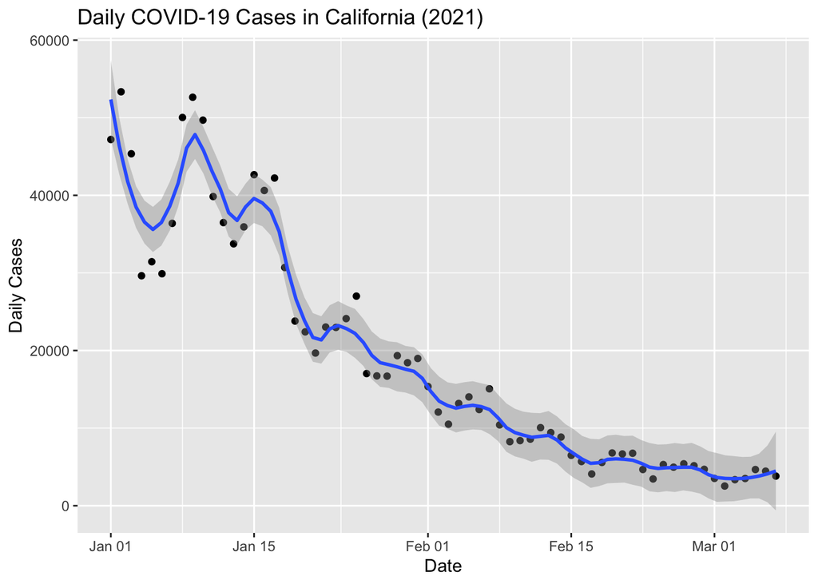

```r
ggplot(covid_ca2021, aes(x = date, y = daily_cases)) +
  geom_point() +
  geom_smooth(method = "loess", span = 0.2) +
  labs(title = "Daily COVID-19 Cases in California (2021)", x = "Date",y = "Daily Cases")
```

### b

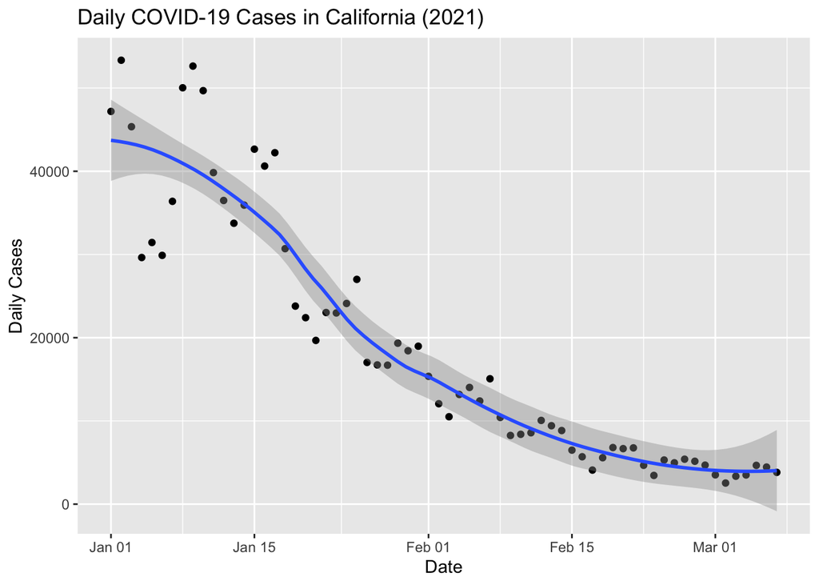

```r
ggplot(covid_ca2021, aes(x = date, y = daily_cases)) +
  geom_point() +
  geom_smooth(method = "loess", span = 0.6) +
  labs(title = "Daily COVID-19 Cases in California (2021)", x = "Date",y = "Daily Cases")
```

### c

Changing the span of the regression line gives it a chance to fit the data better. When we have a span of 0.2, the variability of the curve increases as oppose to 0.6 where the line becomes smoother capturing a more generalized fit.

## Exercise 2

```r
nhanes_samp <- readRDS(url("https://ericwfox.github.io/data/nhanes_samp1.rds"))
```

### a

```r
quadratic_model <- lm(BMI ~ Age + I(Age^2), data = nhanes_samp)

summary(quadratic_model)
```

```
Call:
lm(formula = BMI ~ Age + I(Age^2), data = nhanes_samp)

Residuals:
    Min      1Q  Median      3Q     Max
-11.978  -4.326  -1.419   3.140  34.950

Coefficients:
              Estimate Std. Error t value Pr(>|t|)
(Intercept) 15.5592870  0.8871135  17.539   <2e-16 ***
Age          0.6139386  0.0506965  12.110   <2e-16 ***
I(Age^2)    -0.0062116  0.0006213  -9.997   <2e-16 ***
---
Signif. codes:  0 '***' 0.001 '**' 0.01 '*' 0.05 '.' 0.1 ' ' 1

Residual standard error: 6.411 on 497 degrees of freedom
Multiple R-squared:  0.2751,    Adjusted R-squared:  0.2722
F-statistic: 94.32 on 2 and 497 DF,  p-value: < 2.2e-16
```

$$BMI = 15.5593 + 0.6139 \times \text{Age} - 0.0062 \times \text{Age}^2$$

The $R^2$ in this quadratic model tells us that the variables we used accounts for 27.22 % of the variability in the model which is relatively low.

### b

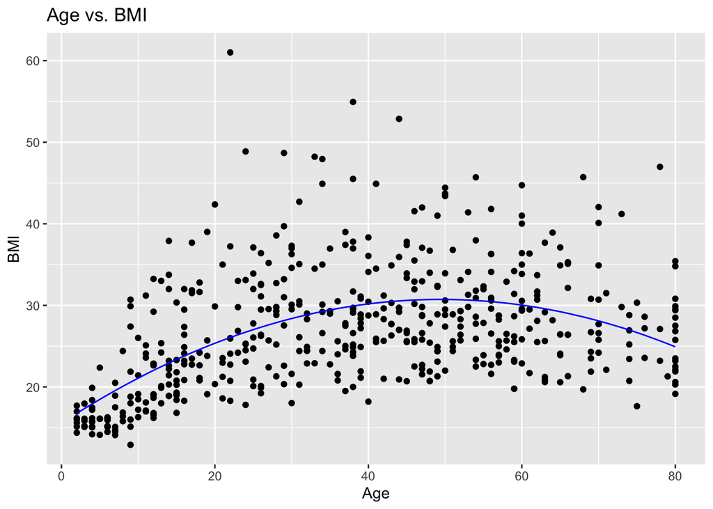

```r
nhanes_samp$fitted <- predict(quadratic_model, newdata = nhanes_samp)

ggplot(nhanes_samp, aes(x = Age, y = BMI)) +
  geom_point() +
  geom_line(aes(y = fitted), color = "blue") +
  labs(title = "Age vs. BMI",
       x = "Age",
       y = "BMI")
```

## c

```r
age_values <- c(20, 40, 60)
predicted_bmi <- predict(quadratic_model, newdata = data.frame(Age = age_values))
predicted_bmi
```

```
       1        2        3
25.35341 30.17825 30.03380
```

### d

```r
third_degree_model <- lm(BMI ~ poly(Age, 3), data = nhanes_samp)

fourth_degree_model <- lm(BMI ~ poly(Age, 4), data = nhanes_samp)

summary(third_degree_model)
```

```
Call:
lm(formula = BMI ~ poly(Age, 3), data = nhanes_samp)

Residuals:
    Min      1Q  Median      3Q     Max
-12.109  -4.389  -1.131   2.879  33.821

Coefficients:
              Estimate Std. Error t value Pr(>|t|)
(Intercept)    27.0183     0.2836  95.263  < 2e-16 ***
poly(Age, 3)1  60.3768     6.3419   9.520  < 2e-16 ***
poly(Age, 3)2 -64.0944     6.3419 -10.106  < 2e-16 ***
poly(Age, 3)3  21.8736     6.3419   3.449  0.00061 ***
---
Signif. codes:  0 '***' 0.001 '**' 0.01 '*' 0.05 '.' 0.1 ' ' 1

Residual standard error: 6.342 on 496 degrees of freedom
Multiple R-squared:  0.2921,    Adjusted R-squared:  0.2878
F-statistic: 68.22 on 3 and 496 DF,  p-value: < 2.2e-16
```

```r
summary(fourth_degree_model)
```

```
Call:
lm(formula = BMI ~ poly(Age, 4), data = nhanes_samp)

Residuals:
    Min      1Q  Median      3Q     Max
-11.830  -4.302  -1.018   3.123  33.629

Coefficients:
              Estimate Std. Error t value Pr(>|t|)
(Intercept)    27.0183     0.2837  95.249  < 2e-16 ***
poly(Age, 4)1  60.3768     6.3428   9.519  < 2e-16 ***
poly(Age, 4)2 -64.0944     6.3428 -10.105  < 2e-16 ***
poly(Age, 4)3  21.8736     6.3428   3.449 0.000612 ***
poly(Age, 4)4  -5.8972     6.3428  -0.930 0.352956
---
Signif. codes:  0 '***' 0.001 '**' 0.01 '*' 0.05 '.' 0.1 ' ' 1

Residual standard error: 6.343 on 495 degrees of freedom
Multiple R-squared:  0.2933,    Adjusted R-squared:  0.2876
F-statistic: 51.37 on 4 and 495 DF,  p-value: < 2.2e-16
```

The regression model for the third and fourth polynomial are very similar. The R<sup>2</sup>, residual standard error, and p-values are all very similar so I would say the third degree polynomial is the better fit in this case. This is because it’s a lot more simple and easier to explain or demonstrate it.

### e

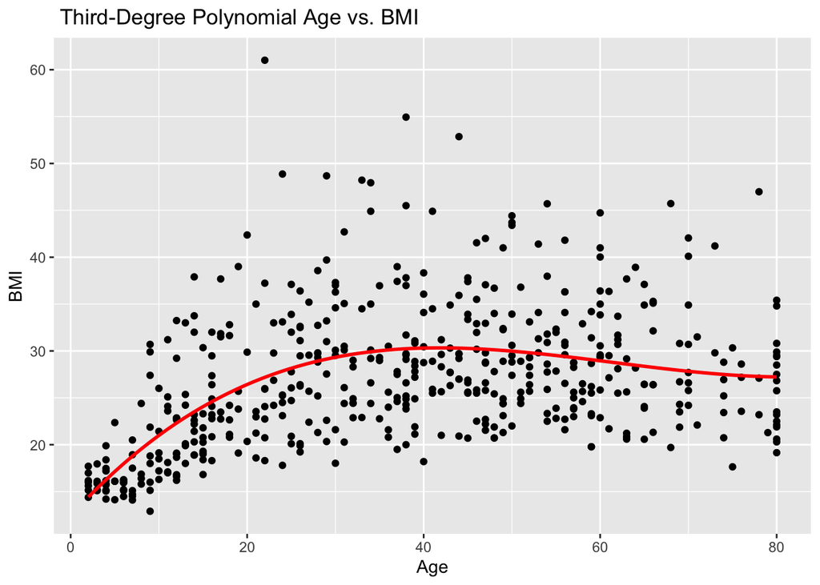

```r
ggplot(nhanes_samp, aes(x = Age, y = BMI)) +
  geom_point() +
  geom_smooth(method = "lm", formula = y ~ poly(x, 3), se = FALSE, color = "red") +
  labs(title = " Third-Degree Polynomial Age vs. BMI", x = "Age",y = "BMI")
```

## Exercise 3

## a

```r
set.seed(123)
x <- runif(300, 0, 10)
eps <- rnorm(300, sd = 1.5)
y <- x + 2*sin(2*x) + 2 + eps
df <- data.frame(x, y)
```

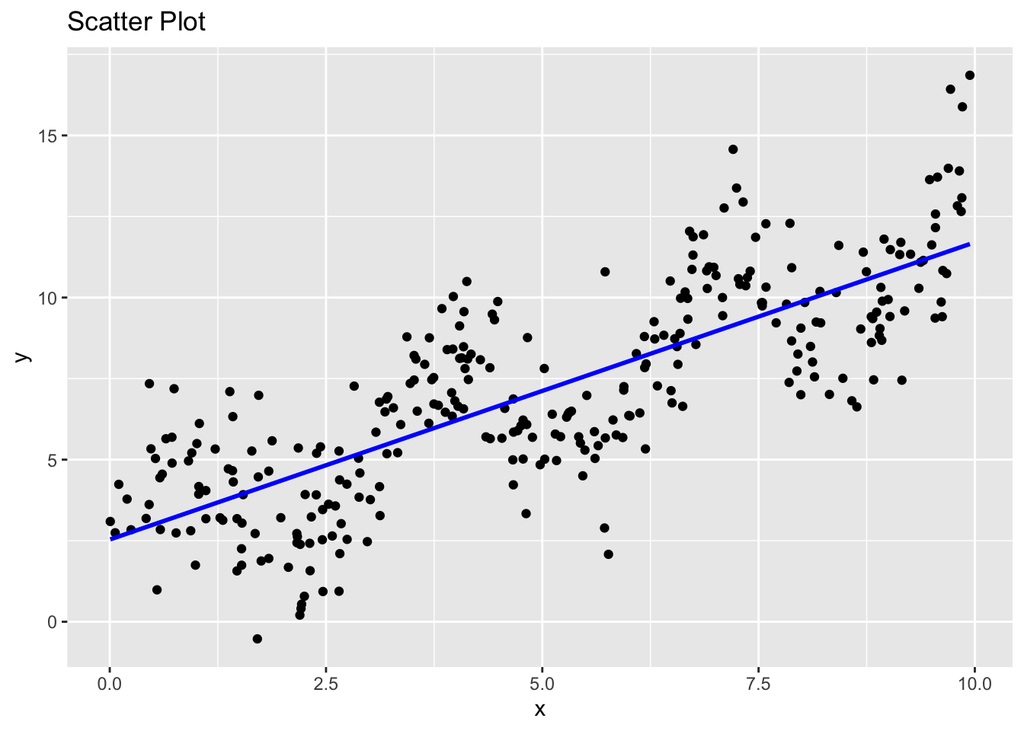

```r
ggplot(df, aes(x = x, y = y)) +
  geom_point() +
  geom_smooth(method = "lm", se = FALSE, color = "blue") +
  labs(title = "Scatter Plot", x = "x",y = "y")
```

This model under fits the data as it is a very general fit, not taking into account every data point and is not capturing the relationship adequately enough.

## b

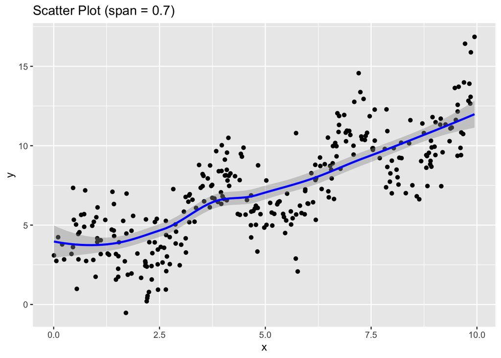

```r
ggplot(df, aes(x = x, y = y)) +
  geom_point() +
  geom_smooth(method = "loess", span = 0.7, color = "blue") +
  labs(title = "Scatter Plot (span = 0.7)",
       x = "x",
       y = "y")
```

This curve is still to much of a general fit to be adequate for the data set. It has more curves but still has a high bias.

### c

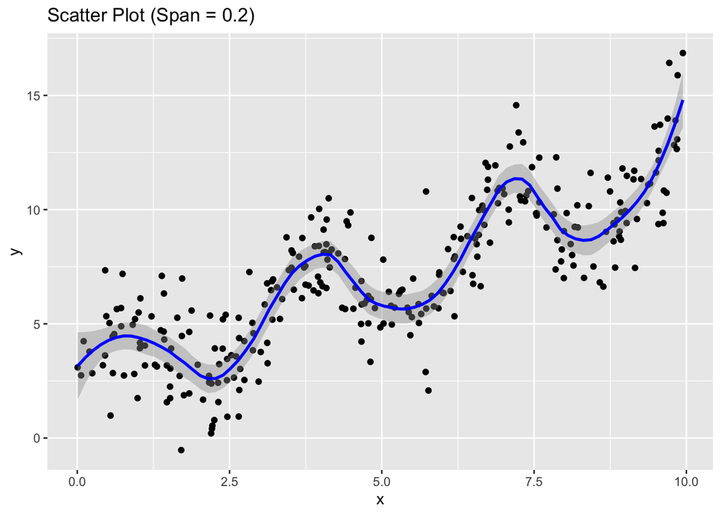

```r
ggplot(df, aes(x = x, y = y)) +
  geom_point() +  # Scatter plot
  geom_smooth(method = "loess", span = 0.2, color = "blue") +
  labs(title = "Scatter Plot (Span = 0.2)",
       x = "x",
       y = "y")
```

The regression curve in this instance fits the data adequately. As oppose to the other regression curves, this one is not over-generalized and is not too specific. It has balance in both bias and variance.

### d

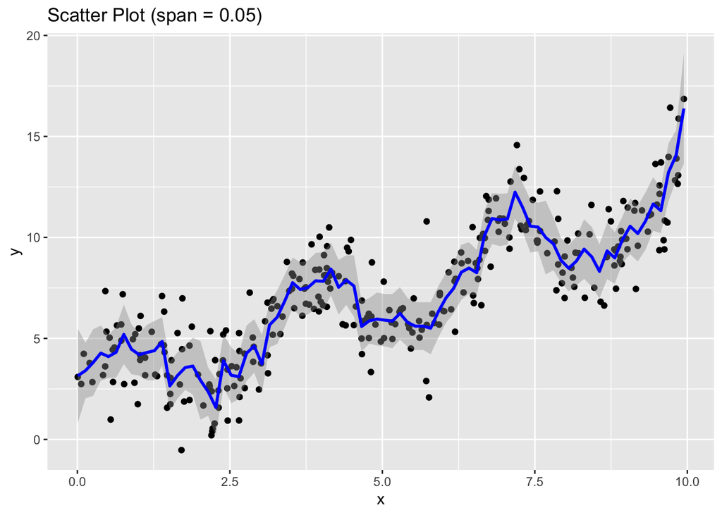

```r
ggplot(df, aes(x = x, y = y)) +
  geom_point() +
  geom_smooth(method = "loess", span = 0.05, color = "blue") +
  labs(title = "Scatter Plot (span = 0.05)",
       x = "x",
       y = "y")
```

The regression curve in this example over fits the data. The bias might be too low with a high variance making it overly sensitive to the data points. This can also lead to it not visualizing underlying patterns very well.

### Exercise 4

```r
set.seed(123)
x <- runif(300, 0, 10)
epsilon <- rnorm(300, mean = 0, sd = 0.25)
y <- x + 2 * sin(2 * x) + 2 + epsilon
df <- data.frame(x, y)
```

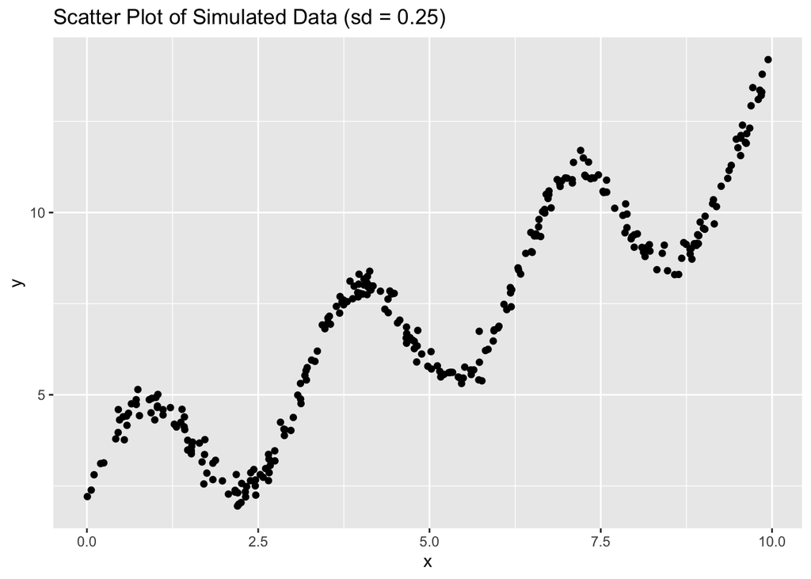

```r
library(ggplot2)
ggplot(df, aes(x = x, y = y)) +
  geom_point() +
  labs(title = "Scatter Plot of Simulated Data (sd = 0.25)", x = "x",y = "y")
```

The decreasing standard deviation changes how the scatter plot looks. In this case, we have data points that are less spread out leading to a tighter clustering due to the decrease on variance.